# portfolio 4

Binrui Yang

5/5/2022

**Discussion:**

**Short Description**

Data Science is one of the fastest-growing job in 21st century, it is a popular and lucrative profession. As a college student who wants to pursue a career in Data Science/Analytics, analyzing this dataset will help me better prepare myself for my future job.

- For the first plot, I am curious to see which state has the most total number of data science related jobs.
- For the second plot, I want to analyze whether different job positions might lead to different salary in each state.
- For the third plot, I want to analyze whether different job positions have different requirement for skills.

**Dataset link:** https://www.kaggle.com/nikhilbhathi/data-scientist-salary-us-glassdoor

The dataset is obtained from Kaggle, it was created by Nikhi Bhathi by crapping the job postings related to the positioon of “Data Scentist” from www.glassdoor.com in USA. There a total number of 742 rows and 42 columns in the original dataset. Each row in the dataset represents a data science related job title, each column has different information regarding the job.

**Dataset Limitation**

One limitation of the dataset is that it only contains 742 unique data science related job, I feel like it might be too small to provide a useful insight. Another limitation is that the author of the dataset didn’t provide information about how he scrapped the data from the website, thus some information could potentially be misleading.

```r
ds_jobs = read_csv('data_cleaned_2021.csv')
names(ds_jobs) = gsub(' ', '_', names(ds_jobs))
names(ds_jobs) = tolower(names(ds_jobs))
```

```r
skill_vector = c('python', 'spark', 'aws', 'excel', 'sql', 'sas', 'keras', 'pytorch', 'scikit', 'tensor', 'hadoop', 'tableau', 'bi', 'flink', 'mongo', 'google_an')

ds_jobs = ds_jobs%>%
  separate('location', into = c('job_city', 'job_state'), sep = ', ', convert = TRUE) %>%
  separate('headquarters', into = c('headquarters_ city', 'headquarters_state'), sep = ', ', convert = TRUE) %>%
  pivot_longer(skill_vector, names_to = 'skill', values_to = 'required')
```

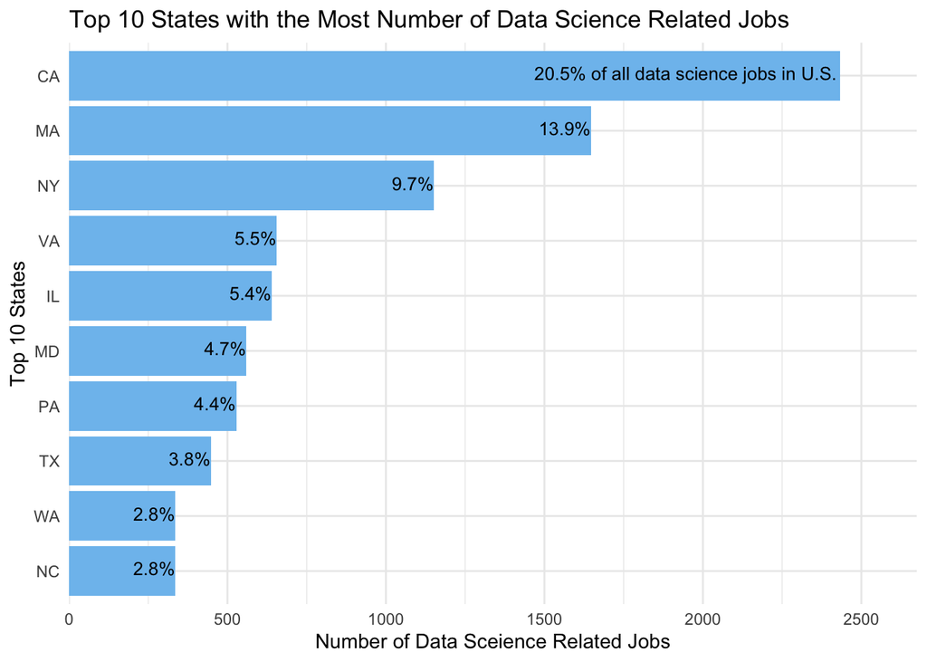

```r
job_count = ds_jobs %>%
  group_by(job_location) %>%
  summarise(cnt = n()) %>%
  mutate(perc = paste0(sprintf("%4.1f", cnt / sum(cnt) * 100), "%"), ) %>%
  arrange(desc(cnt)) %>%
  slice(1:10)

job_count %>%
  mutate(perc = if_else(row_number() == 1, paste(perc, "of all data science jobs in U.S."), perc)) %>%
  ggplot(aes(x = cnt, y = reorder(job_location, cnt))) +
  geom_bar(stat = 'identity', fill = "skyblue2") +
  geom_text(aes(label = perc), hjust = 1.01, vjust = .3, nudge_x = -.1, size = 3.5) +
  ggtitle("Top 10 States with the Most Number of Data Science Related Jobs") +
  labs(x= 'Number of Data Sceience Related Jobs', y = 'Top 10 States') +
  scale_x_continuous(expand = c(0, 0, 0.1, 0.1)) +
  theme(axis.ticks = element_blank(),
  panel.grid.major.y = element_blank()) +
  theme_minimal()
```

**For the first plot, I am curious to see which state has the most total number of data science related jobs.**

In order to create this plot, first I group the jobs into its location (State), making two new columns that record the total number of jobs in each state and its percentage. Since I want to visualize both count and percentage in a bar plot, I used mutate() to add “of all data science jobs in US” in the first row of the percentage column so that the visualization is more clear. Before I make the plot, I sort my data and select the top 10 states with most data science jobs. Finally I used geom_bar() to create the bar graph.

Unsurprising, California has the most number of data science related jobs. One unexpecting finding I have when looking at the graph is that Massachusetts has a large number of data science jobs.

```r
top_state = ds_jobs %>%
  group_by(job_location) %>%
  summarise(cnt = n()) %>%
  ungroup() %>%
  slice_max(cnt, n = 10) %>%
  pull(job_location)
ds_jobs = ds_jobs %>%
  filter(job_title_sim !='na') %>%
  filter(job_title_sim !='director')

job_salary = ds_jobs%>%
  group_by(job_title_sim, job_location) %>%
  summarise(n_title = n(), ave_salary = sum(`avg_salary(k)`/n_title)) %>%
  filter(job_location %in% top_state)
```

**For the second plot, I want to analyze whether different job positions might lead to different salary in each state.**

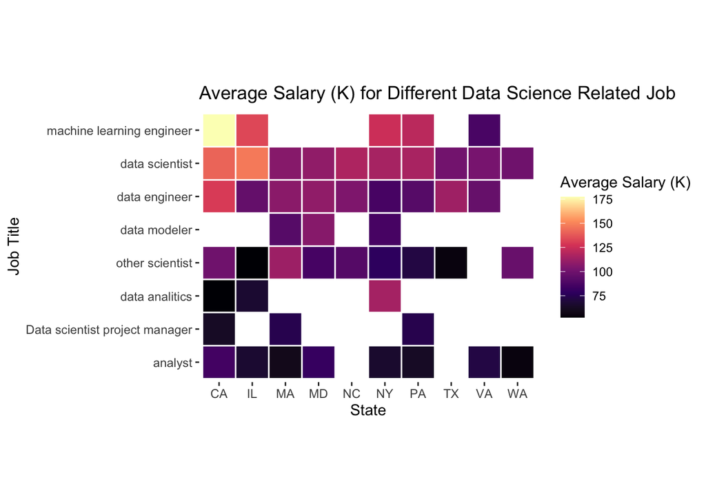

```r
ggplot(job_salary) +
  geom_tile(aes(job_location, reorder(job_title_sim, ave_salary),fill = ave_salary), col = "white", lwd = 0.5) +
  scale_fill_viridis_c(option = "magma") +
  ggtitle("Average Salary (K) for Different Data Science Related Job") +
  labs(x= 'State', y = 'Job Title', fill = "Average Salary (K)") +
  coord_equal()+
  theme(panel.background=element_rect(fill="white", colour="white"))
```

```r
top_5_skills = ds_jobs %>%
  select(c(skill, required)) %>%
  filter(required == 1) %>%
  group_by(skill) %>%
  count(required, sort = TRUE) %>%
  head(5) %>%
  pull(skill)

skill_count = ds_jobs %>%
  select(c(job_title_sim, skill, required)) %>%
  filter(skill %in% top_5_skills) %>%
  filter(required == 1) %>%
  group_by(skill,job_title_sim) %>%
  count(required, sort = TRUE)
```

**For the third plot, I want to analyze whether different job positions have different requirement for skills.**

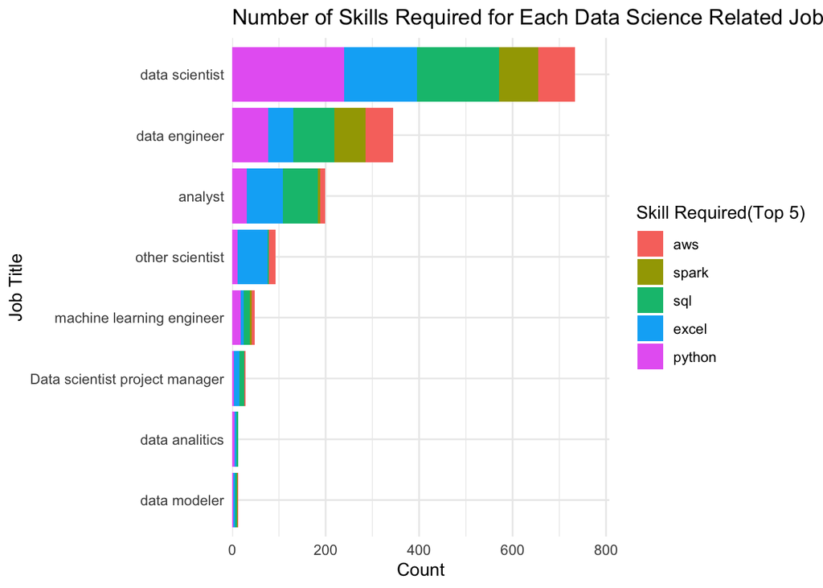

```r
ggplot(skill_count, aes(x = n, y = reorder(job_title_sim, n), fill = reorder(skill, n))) +
  geom_bar(stat = 'identity') +
  ggtitle("Number of Skills Required for Each Data Science Related Jobs") +
  labs(x= 'Count', y = 'Job Title', fill = 'Skill Required(Top 5)') +
  scale_x_continuous(expand = c(0, 0, 0.1, 0.1)) +
  theme(axis.ticks = element_blank(),
  panel.grid.major.y = element_blank()) +
  theme_minimal()
```

Lastly, I decided to extend my first portfolio by adding one plot exploring the skills required for each data science job. Therefore, I first select the top 5 most frequent skills required and stored them in a vector. Then I count the number of different data science-related jobs and also count how many of each 5 skills are required by them. Finally, I used geom_bar to show the number of each data science-related job and how many of those skills are required by each related job.